# Importing packages

```python
import pandas as pd
import numpy as np
from scipy import stats
from random import randint
```

# Reading Raw Data

```python
df =pd.read_excel("AggregateData_linear.xlsx",sheet_name='Direct Materials')
```

# Displaying Top 5 Rows from Raw Data

```python
df.head()
```

|  | dosage_form_code | material_name | cc2_name | cost | quantity | unit_cost | costing_lot_size |
| --- | --- | --- | --- | --- | --- | --- | --- |
| 0 | FCT | ALENDRONATE SDZ 70MG 4TAB TH | API | 1370.520000 | 6897.430000 | 0.198700 | 17500 |
| 1 | FCT | ALENDRONATE SDZ 70MG 4TAB TH | Other Materials | 7.017778 | 2833.981889 | 0.014453 | 17500 |
| 2 | FCT | ALENDRONATE SDZ 70MG 4TAB TH | Packaging | 150.517500 | 23720.277250 | 0.020731 | 17500 |
| 3 | FCT | AMYZOL 10MG 100FCT HRV | API | 1084.520000 | 5236.170000 | 0.207121 | 5000 |
| 4 | FCT | AMYZOL 10MG 100FCT HRV | Other Materials | 13.740000 | 6507.121417 | 0.011071 | 5000 |

```python
import re
```

```python
df1 =df.copy()
```

# Finding Material Weight Value and Material Package Size from material_name column

```python
for i in range(len(df)):
    #print(df.loc[i,'material_name'])
    #print( re.findall('\d+',df.loc[i,'material_name']))
    l1 = re.findall('\d+',df.loc[i,'material_name'])
    df1.loc[i,'material_weight'] = l1[0]
    df1.loc[i,'material_package_size'] = l1[1]
```

# Displaying Material Weight Value and Material Package Size as column values

```python
df1.head()
```

|  | dosage_form_code | material_name | cc2_name | cost | quantity | unit_cost | costing_lot_size | material_weight | material_package_size |
| --- | --- | --- | --- | --- | --- | --- | --- | --- | --- |
| 0 | FCT | ALENDRONATE SDZ 70MG 4TAB TH | API | 1370.520000 | 6897.430000 | 0.198700 | 17500 | 70 | 4 |
| 1 | FCT | ALENDRONATE SDZ 70MG 4TAB TH | Other Materials | 7.017778 | 2833.981889 | 0.014453 | 17500 | 70 | 4 |
| 2 | FCT | ALENDRONATE SDZ 70MG 4TAB TH | Packaging | 150.517500 | 23720.277250 | 0.020731 | 17500 | 70 | 4 |
| 3 | FCT | AMYZOL 10MG 100FCT HRV | API | 1084.520000 | 5236.170000 | 0.207121 | 5000 | 10 | 100 |
| 4 | FCT | AMYZOL 10MG 100FCT HRV | Other Materials | 13.740000 | 6507.121417 | 0.011071 | 5000 | 10 | 100 |

```python
df1.columns
```

```
Index(['dosage_form_code', 'material_name', 'cc2_name', 'cost', 'quantity',
       'unit_cost', 'costing_lot_size', 'material_weight',
       'material_package_size'],
      dtype='object')
```

# Information About Columns Data Type

```python
df1.info()
```

```
<class 'pandas.core.frame.DataFrame'>
RangeIndex: 1435 entries, 0 to 1434
Data columns (total 9 columns):
 #   Column                 Non-Null Count  Dtype
---  ------                 --------------  -----
 0   dosage_form_code       1435 non-null   object
 1   material_name          1435 non-null   object
 2   cc2_name               1435 non-null   object
 3   cost                   1435 non-null   float64
 4   quantity               1435 non-null   float64
 5   unit_cost              1435 non-null   float64
 6   costing_lot_size       1435 non-null   int64
 7   material_weight        1435 non-null   object
 8   material_package_size  1435 non-null   object
dtypes: float64(3), int64(1), object(5)
memory usage: 101.0+ KB
```

# Changing Data Type of Material Weight Value and Material Package Size to Numeric

```python
df1["material_weight"] = pd.to_numeric(df1["material_weight"])
df1["material_package_size"] = pd.to_numeric(df1["material_package_size"])
```

```python
df1['dosage_form_code'].value_counts()
```

```
FCT    802
TAB    492
HGC    141
Name: dosage_form_code, dtype: int64
```

```python
df1['cc2_name'].value_counts()
```

```
Packaging          479
Other Materials    478
API                478
Name: cc2_name, dtype: int64
```

# EDA- Exploratory data analysis

In statistics, exploratory data analysis is an approach of analyzing data sets to summarize their main characteristics, often using statistical graphics and other data visualization methods.

```python
import matplotlib.pyplot as plt
%matplotlib inline
import seaborn as sns
# For Preprocessing
from sklearn.preprocessing import LabelEncoder, OneHotEncoder, StandardScaler
```

```python
print('Data Shape:', df1.shape)
```

```
Data Shape: (1435, 9)
```

# Checking if null values are present in data to work on

```python
df1.isnull().sum()
```

```
dosage_form_code         0
material_name            0
cc2_name                 0
cost                     0
quantity                 0
unit_cost                0
costing_lot_size         0
material_weight          0
material_package_size    0
dtype: int64
```

Univariate Anlysis

```python
df1.info()
```

```
<class 'pandas.core.frame.DataFrame'>
RangeIndex: 1435 entries, 0 to 1434
Data columns (total 9 columns):
 #   Column                 Non-Null Count  Dtype
---  ------                 --------------  -----
 0   dosage_form_code       1435 non-null   object
 1   material_name          1435 non-null   object
 2   cc2_name               1435 non-null   object
 3   cost                   1435 non-null   float64
 4   quantity               1435 non-null   float64
 5   unit_cost              1435 non-null   float64
 6   costing_lot_size       1435 non-null   int64
 7   material_weight        1435 non-null   int64
 8   material_package_size  1435 non-null   int64
dtypes: float64(3), int64(3), object(3)
memory usage: 101.0+ KB
```

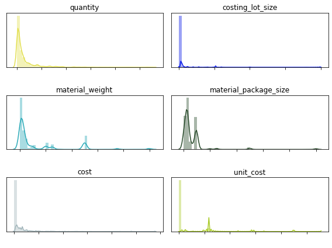

```python
fig, axes = plt.subplots(nrows = 3, ncols = 2, sharex = False, figsize=(8, 6))
columns = ['quantity', 'costing_lot_size', 'material_weight', 'material_package_size', 'cost','unit_cost']
# Generating random colors
colors = []
for i in range(len(columns)):
  colors.append('#%06X' % randint(0, 0xFFFFFF))
for ax, col, color in zip(axes.flat, columns, colors):
  sns.distplot(a = df1[col], bins = 50, ax = ax, color = color)
  ax.set_title(col)
  plt.setp(axes, yticks=[])
  ax.set_xlabel(' ')
  ax.set_xticklabels(labels = ' ')
  ax.grid(False)
plt.tight_layout()
```

```python
df1.describe()
```

|  | cost | quantity | unit_cost | costing_lot_size | material_weight | material_package_size |
| --- | --- | --- | --- | --- | --- | --- |
| count | 1435.000000 | 1435.000000 | 1435.000000 | 1.435000e+03 | 1435.000000 | 1435.000000 |
| mean | 3158.745111 | 30900.590395 | 46.118333 | 4.526437e+04 | 119.733101 | 61.862021 |
| std | 9888.944669 | 55662.701333 | 152.399516 | 2.354677e+05 | 198.418118 | 110.123028 |
| min | 0.166000 | 3.672000 | 0.001056 | 1.000000e+02 | 0.000000 | 2.000000 |
| 25% | 46.809889 | 3368.487104 | 0.014026 | 2.500000e+03 | 10.000000 | 20.000000 |
| 50% | 204.523333 | 10870.443692 | 0.071629 | 6.933000e+03 | 20.000000 | 30.000000 |
| 75% | 1726.905000 | 30640.492833 | 0.501350 | 2.310000e+04 | 100.000000 | 90.000000 |
| max | 144602.070000 | 551084.312333 | 1108.904777 | 4.000000e+06 | 1000.000000 | 1000.000000 |

```python
data = df1.copy()
```

# Find Outliers for cost

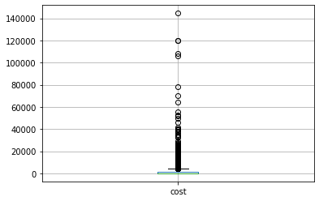

```python
#sns.boxplot(df1['costing_lot_size'])
figure = df1.boxplot(column="cost")
```

```python
IQR = df1.cost.quantile(0.75)- df1.cost.quantile(0.25)
IQR
```

```
1680.095111111111
```

```python
#extreme outliers
lb = df1.cost.quantile(0.25)-(IQR*3)
ub = df1.cost.quantile(0.75)+(IQR*3)
print(lb),print(ub)
```

```
-4993.475444444444
6767.190333333333
```

```
(None, None)
```

```python
# removing rows where 'cost' > 6767.190333333333
data.drop(data[data['cost'] > 6767.190333333333].index, inplace = True)
```

Outliers for Quantity

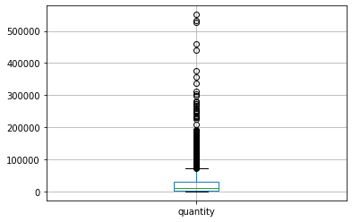

```python
figure = df1.boxplot(column="quantity")
```

```python
IQR_quantity = df1.quantity.quantile(0.75)- df1.quantity.quantile(0.25)
IQR_quantity
```

```
27272.005729166664
```

```python
#extreme outliers
lb_quantity = df1.quantity.quantile(0.25)-(IQR_quantity*3)
ub_quantity = df1.quantity.quantile(0.75)+(IQR_quantity*3)
print(lb_quantity),print(ub_quantity)
```

```
-78447.53008333333
112456.51002083332
```

```
(None, None)
```

```python
# removing rows where 'quantity' > 112456.51002083332
data.drop(data[data['quantity'] > 112456.51002083332].index, inplace = True)
```

outlier for costing_lot_size

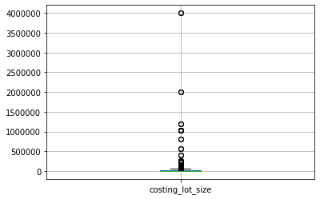

```python
figure = df1.boxplot(column="costing_lot_size")
```

```python
IQR_costing_lot_size = df1.costing_lot_size.quantile(0.75)- df1.costing_lot_size.quantile(0.25)
IQR_costing_lot_size
```

```
20600.0
```

```python
#extreme outliers
lb_costing_lot_size = df1.costing_lot_size.quantile(0.25)-(IQR_costing_lot_size*3)
ub_costing_lot_size = df1.costing_lot_size.quantile(0.75)+(IQR_costing_lot_size*3)
print(lb_costing_lot_size),print(ub_costing_lot_size)
```

```
-59300.0
84900.0
```

```
(None, None)
```

```python
# removing rows where 'costing_lot_size' > 84900.0
data.drop(data[data['costing_lot_size'] > 84900.0].index, inplace = True)
```

After removing Outliers

```python
df1.shape
```

```
(1435, 9)
```

```python
data.shape
```

```
(1136, 9)
```

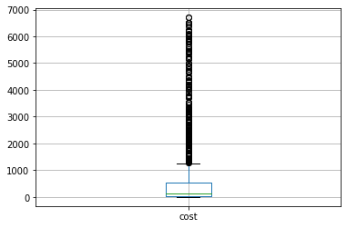

```python
figure = data.boxplot(column="cost")
```

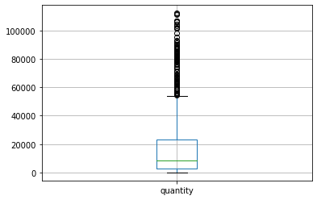

```python
figure = data.boxplot(column="quantity")
```

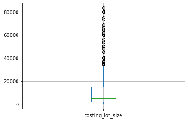

```python
figure = data.boxplot(column="costing_lot_size")
```

What is the average cost of 'dosage_form_code'?

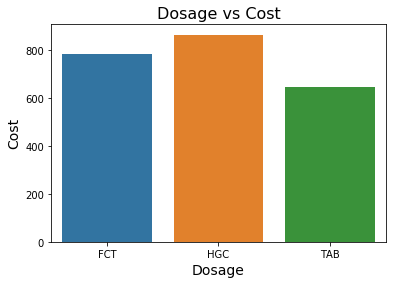

```python
data2 = pd.DataFrame(data.groupby(['dosage_form_code'], as_index = False)['cost'].mean())
plt.figure(figsize = [6, 4])
sns.barplot(x = 'dosage_form_code', y = 'cost', data = data2, linewidth = 2.5)
plt.xlabel('Dosage', size = 14)
plt.ylabel('Cost', size = 14)
plt.title('Dosage vs Cost', size = 16)
plt.show()
```

What is the average cost of 'cc2_name'?

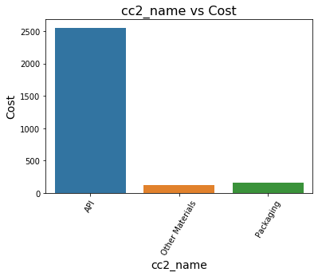

```python
data2 = pd.DataFrame(data.groupby(['cc2_name'], as_index = False)['cost'].mean())
plt.figure(figsize = [6, 4])
sns.barplot(x = 'cc2_name', y = 'cost', data = data2, linewidth = 2.5)
plt.xlabel('cc2_name', size = 14)
plt.ylabel('Cost', size = 14)
plt.xticks(rotation=60)
plt.title('cc2_name vs Cost', size = 16)
plt.show()
```

costing_lot_size vs cost

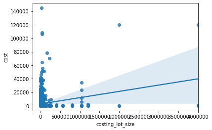

```python
sns.regplot(x="costing_lot_size",y="cost",data=df1)
```

After removing Outliers

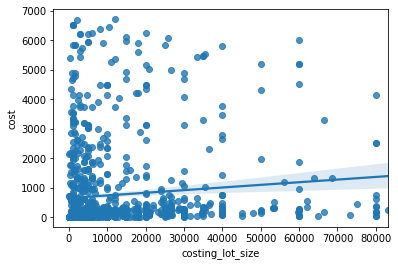

```python
sns.regplot(x="costing_lot_size",y="cost",data=data)
```

material_package_size vs cost

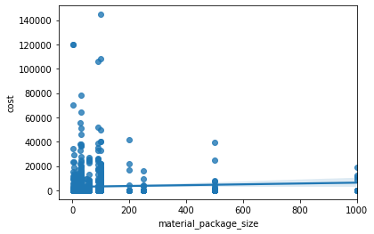

```python
sns.regplot(x="material_package_size",y="cost",data=df1)
```

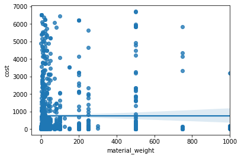

```python
sns.regplot(x="material_weight",y="cost",data=data)
```

quantity vs cost

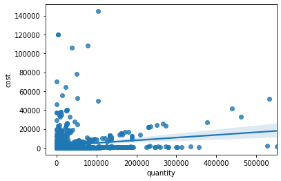

```python
sns.regplot(x="quantity",y="cost",data=df1)
```

After removing Outliers

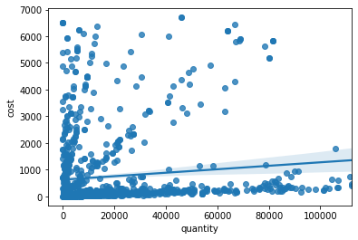

```python
sns.regplot(x="quantity",y="cost",data=data)
```

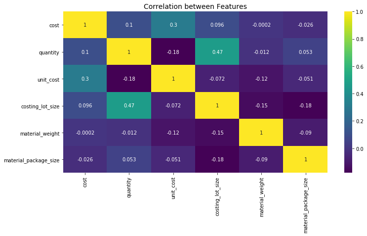

```python
figure = plt.figure(figsize = [12, 6])
sns.heatmap(data.corr(), annot = True, cmap = 'viridis')
plt.title('Correlation between Features', size = 14)
plt.show()
```

# Feature encoding

```python
data = pd.get_dummies(data = data, columns = ['dosage_form_code','cc2_name'])
print('Data Shape:', data.shape)
```

```
Data Shape: (1136, 13)
```

```python
data.head()
```

|  | material_name | cost | quantity | unit_cost | costing_lot_size | material_weight | material_package_size | dosage_form_code_FCT | dosage_form_code_HGC | dosage_form_code_TAB | cc2_name_API | cc2_name_Other Materials | cc2_name_Packaging |
| --- | --- | --- | --- | --- | --- | --- | --- | --- | --- | --- | --- | --- | --- |
| 0 | ALENDRONATE SDZ 70MG 4TAB TH | 1370.520000 | 6897.430000 | 0.198700 | 17500 | 70 | 4 | 1 | 0 | 0 | 1 | 0 | 0 |
| 1 | ALENDRONATE SDZ 70MG 4TAB TH | 7.017778 | 2833.981889 | 0.014453 | 17500 | 70 | 4 | 1 | 0 | 0 | 0 | 1 | 0 |
| 2 | ALENDRONATE SDZ 70MG 4TAB TH | 150.517500 | 23720.277250 | 0.020731 | 17500 | 70 | 4 | 1 | 0 | 0 | 0 | 0 | 1 |
| 3 | AMYZOL 10MG 100FCT HRV | 1084.520000 | 5236.170000 | 0.207121 | 5000 | 10 | 100 | 1 | 0 | 0 | 1 | 0 | 0 |
| 4 | AMYZOL 10MG 100FCT HRV | 13.740000 | 6507.121417 | 0.011071 | 5000 | 10 | 100 | 1 | 0 | 0 | 0 | 1 | 0 |

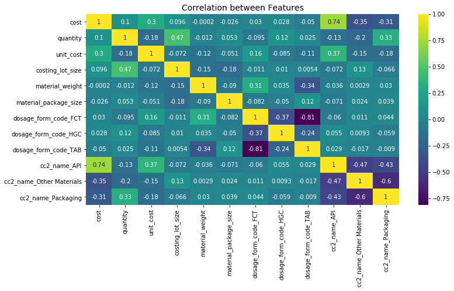

```python
figure = plt.figure(figsize = [12, 6])
sns.heatmap(data.corr(), annot = True, cmap = 'viridis')
plt.title('Correlation between Features', size = 14)
plt.show()
```

```python
data.head()
```

|  | material_name | cost | quantity | unit_cost | costing_lot_size | material_weight | material_package_size | dosage_form_code_FCT | dosage_form_code_HGC | dosage_form_code_TAB | cc2_name_API | cc2_name_Other Materials | cc2_name_Packaging |
| --- | --- | --- | --- | --- | --- | --- | --- | --- | --- | --- | --- | --- | --- |
| 0 | ALENDRONATE SDZ 70MG 4TAB TH | 1370.520000 | 6897.430000 | 0.198700 | 17500 | 70 | 4 | 1 | 0 | 0 | 1 | 0 | 0 |
| 1 | ALENDRONATE SDZ 70MG 4TAB TH | 7.017778 | 2833.981889 | 0.014453 | 17500 | 70 | 4 | 1 | 0 | 0 | 0 | 1 | 0 |
| 2 | ALENDRONATE SDZ 70MG 4TAB TH | 150.517500 | 23720.277250 | 0.020731 | 17500 | 70 | 4 | 1 | 0 | 0 | 0 | 0 | 1 |
| 3 | AMYZOL 10MG 100FCT HRV | 1084.520000 | 5236.170000 | 0.207121 | 5000 | 10 | 100 | 1 | 0 | 0 | 1 | 0 | 0 |
| 4 | AMYZOL 10MG 100FCT HRV | 13.740000 | 6507.121417 | 0.011071 | 5000 | 10 | 100 | 1 | 0 | 0 | 0 | 1 | 0 |

# Modeling

```python
X = data.drop(['material_name','cost','unit_cost'], axis = 1)
y = data['cost']
```

```python
print('X Shape:', X.shape)
print('y Shape:', y.shape)
```

```
X Shape: (1136, 10)
y Shape: (1136,)
```

```python
from sklearn.feature_selection import SelectFromModel
# For metrics evaluation
from sklearn.metrics import mean_squared_error, r2_score
# For Data Modeling and Evaluation
from sklearn.model_selection import train_test_split
from sklearn.linear_model import LinearRegression, Ridge, Lasso
from sklearn.ensemble import RandomForestRegressor
```

```python
X_train, X_test, y_train, y_test = train_test_split(X, y, test_size = 0.2, random_state = 42)
```

# Feature Selection

Feature Selection using Random Forest

```python
sel = SelectFromModel(RandomForestRegressor(n_estimators = 100))
sel.fit(X_train, y_train)
selected_feat= X_train.columns[(sel.get_support())]
print('Total Features Selected are', len(selected_feat))
print('Features:', selected_feat)
```

```
Total Features Selected are 2
Features: Index(['quantity', 'cc2_name_API'], dtype='object')
```

Pearson Correlation

```python
ls = ['quantity', 'costing_lot_size', 'material_weight', 'material_package_size']
correlation = pd.DataFrame(np.abs([stats.pearsonr(data[i], data['cost']) for i in ls]), index = ls, columns = ['Pearson Coef.', 'p-value'])
correlation.transpose()
```

|  | quantity | costing_lot_size | material_weight | material_package_size |
| --- | --- | --- | --- | --- |
| Pearson Coef. | 0.104542 | 0.095862 | 0.000204 | 0.026398 |
| p-value | 0.000417 | 0.001217 | 0.994518 | 0.374054 |

# ANOVA (Analysis of Variance)

----ANOVA is used when there is one categorical feature and one numerical feature

ANOVA on "dosage_form_code"

```python
df.dosage_form_code.value_counts()
```

```
FCT    802
TAB    492
HGC    141
Name: dosage_form_code, dtype: int64
```

```python
grouped_test = df[['dosage_form_code', 'cost']].groupby(['dosage_form_code'])
F_score, p_value = stats.f_oneway(grouped_test.get_group('FCT')['cost'],
                                  grouped_test.get_group('TAB')['cost'],
                                  grouped_test.get_group('HGC')['cost'])
print('F-Score:', F_score, 'p-value:', p_value)
```

```
F-Score: 4.4819510518920955 p-value: 0.011470445985800444
```

ANOVA on "cc2_name"

```python
df.cc2_name.value_counts()
```

```
Packaging          479
Other Materials    478
API                478
Name: cc2_name, dtype: int64
```

```python
grouped_test = df[['cc2_name', 'cost']].groupby(['cc2_name'])
F_score, p_value = stats.f_oneway(grouped_test.get_group('Packaging')['cost'],
                                  grouped_test.get_group('API')['cost'],
                                  grouped_test.get_group('Other Materials')['cost'])
print('F-Score:', F_score, 'p-value:', p_value)
```

```
F-Score: 158.79035485282765 p-value: 5.181672879519068e-63
```

# Model Building

```python
#X = df1.drop(['material_name','cost','unit_cost'], axis = 1)
#y = df1['cost']
```

```python
#print('X Shape:', X.shape)
#print('y Shape:', y.shape)
```

```python
def PlotScore(y_train, y_train_pred, y_test, y_test_pred):
  '''
  Plot visual of acutal and predicted for train & test data
  y_train: actual values of y train
  y_train_pred: predicted values of y_train
  y_test: actual values of y_test
  y_test_pred: predicted values of y_test
  '''
  plt.figure(figsize = [13.66, 6])
  plt.subplot(1, 2, 1)
  sns.lineplot(x = y_train, y = y_train_pred, marker = 'o')
  plt.xlabel('Actual')
  plt.ylabel('Predicted')
  plt.title('For Train Data')

  plt.subplot(1, 2, 2)
  sns.lineplot(x = y_test, y = y_test_pred, marker = 'o')
  plt.xlabel('Actual')
  plt.ylabel('Predicted')
  plt.title('For Test Data')
  plt.show()
```

Linear Regression

```
Acutal Values: 990     288.429167
1151     19.921111
357      53.503750
1049     49.801111
404      23.854667
Name: cost, dtype: float64
Predicted Values: [133 204  62  27 302]
RMSE (Train Data): 830.5
RMSE (Test Data): 830.5
R-Squared (Train Data): 59.0 %
R-Squared (Test Data): 64.0 %
```

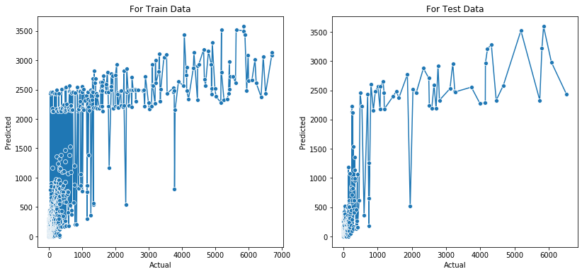

```python
model = LinearRegression()

model.fit(X_train, y_train)

y_train_pred = np.abs(model.predict(X_train).astype('int'))
y_test_pred = np.abs(model.predict(X_test).astype('int'))

print('Acutal Values:', y_test[0:5])
print('Predicted Values:', y_test_pred[0:5])
# Estimating RMSE on Train & Test Data
print('RMSE (Train Data):', np.round(np.sqrt(mean_squared_error(y_true = y_test, y_pred = y_test_pred)), decimals = 2))
print('RMSE (Test Data):', np.round(np.sqrt(mean_squared_error(y_true = y_test, y_pred = y_test_pred)), decimals = 2))
# Estimating R-Squared on Train & Test Data
print('R-Squared (Train Data):', np.round(model.score(X_train, y_train), decimals = 2)*100, '%')
print('R-Squared (Test Data):', np.round(model.score(X_test, y_test), decimals = 2)*100, '%')
# Plotting Acutal vs Predicted values
PlotScore(y_train, y_train_pred, y_test, y_test_pred)
```

RandomForest Regressor

```
Acutal Values: 990     288.429167
1151     19.921111
357      53.503750
1049     49.801111
404      23.854667
Name: cost, dtype: float64
Predicted Values: [141  51  59  74 121]
RMSE (Train Data): 537.1
RMSE (Test Data): 537.1
R-Squared (Train Data): 98.0 %
R-Squared (Test Data): 85.0 %
```

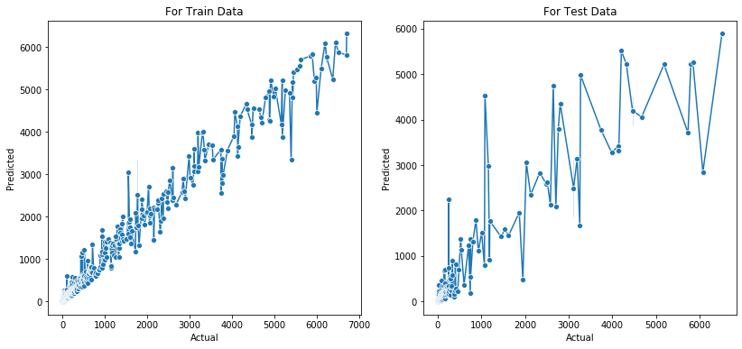

```python
randomforest = RandomForestRegressor(random_state = 42)
randomforest.fit(X_train, y_train)
y_train_pred = np.abs(randomforest.predict(X_train).astype('int'))
y_test_pred = np.abs(randomforest.predict(X_test).astype('int'))

print('Acutal Values:', y_test[0:5])
print('Predicted Values:', y_test_pred[0:5])
# Estimating RMSE on Train & Test Data
print('RMSE (Train Data):', np.round(np.sqrt(mean_squared_error(y_true = y_test, y_pred = y_test_pred)), decimals = 2))
print('RMSE (Test Data):', np.round(np.sqrt(mean_squared_error(y_true = y_test, y_pred = y_test_pred)), decimals = 2))
# Estimating R-Squared on Train & Test Data
print('R-Squared (Train Data):', np.round(randomforest.score(X_train, y_train), decimals = 2)*100, '%')
print('R-Squared (Test Data):', np.round(randomforest.score(X_test, y_test), decimals = 2)*100, '%')
# Plotting Acutal vs Predicted values
PlotScore(y_train, y_train_pred, y_test, y_test_pred)
```

GradientBoostingRegressor

```
Acutal Values: 990     288.429167
1151     19.921111
357      53.503750
1049     49.801111
404      23.854667
Name: cost, dtype: float64
Predicted Values: [112 104  63 142 173]
RMSE (Train Data): 514.98
RMSE (Test Data): 514.98
R-Squared (Train Data): 93.0 %
R-Squared (Test Data): 86.0 %
```

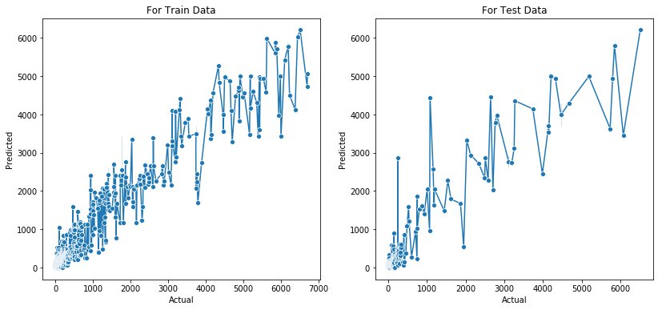

```python
from sklearn.ensemble import GradientBoostingRegressor

gbr = GradientBoostingRegressor(random_state=0)
gbr.fit(X_train, y_train)

y_train_pred = np.abs(gbr.predict(X_train).astype('int'))
y_test_pred = np.abs(gbr.predict(X_test).astype('int'))

print('Acutal Values:', y_test[0:5])
print('Predicted Values:', y_test_pred[0:5])
# Estimating RMSE on Train & Test Data
print('RMSE (Train Data):', np.round(np.sqrt(mean_squared_error(y_true = y_test, y_pred = y_test_pred)), decimals = 2))
print('RMSE (Test Data):', np.round(np.sqrt(mean_squared_error(y_true = y_test, y_pred = y_test_pred)), decimals = 2))
# Estimating R-Squared on Train & Test Data
print('R-Squared (Train Data):', np.round(gbr.score(X_train, y_train), decimals = 2)*100, '%')
print('R-Squared (Test Data):', np.round(gbr.score(X_test, y_test), decimals = 2)*100, '%')
# Plotting Acutal vs Predicted values
PlotScore(y_train, y_train_pred, y_test, y_test_pred)
```

```
[10:17:46] WARNING: C:/Users/Administrator/workspace/xgboost-win64_release_1.3.0/src/objective/regression_obj.cu:170: reg:linear is now deprecated in favor of reg:squarederror.
Acutal Values: 990     288.429167
1151     19.921111
357      53.503750
1049     49.801111
404      23.854667
Name: cost, dtype: float64
Predicted Values: [116  59  35  62  24]
RMSE (Train Data): 582.42
RMSE (Test Data): 582.42
R-Squared (Train Data): 96.0 %
R-Squared (Test Data): 82.0 %
```

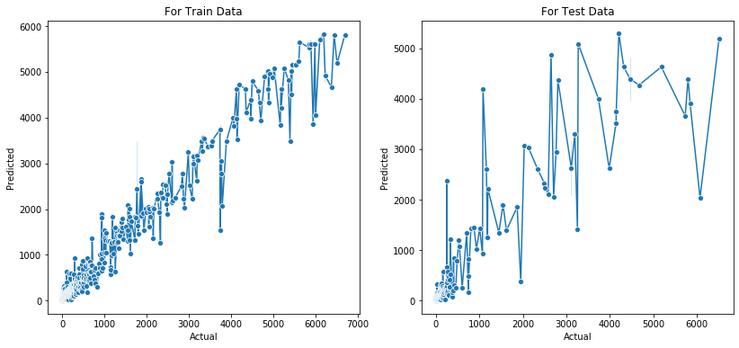

```python
#xgboost
import xgboost as xg
xgb_r = xg.XGBRegressor(objective ='reg:linear',
                  n_estimators = 10, seed = 123)
xgb_r.fit(X_train, y_train)

y_train_pred = np.abs(xgb_r.predict(X_train).astype('int'))
y_test_pred = np.abs(xgb_r.predict(X_test).astype('int'))

print('Acutal Values:', y_test[0:5])
print('Predicted Values:', y_test_pred[0:5])
# Estimating RMSE on Train & Test Data
print('RMSE (Train Data):', np.round(np.sqrt(mean_squared_error(y_true = y_test, y_pred = y_test_pred)), decimals = 2))
print('RMSE (Test Data):', np.round(np.sqrt(mean_squared_error(y_true = y_test, y_pred = y_test_pred)), decimals = 2))
# Estimating R-Squared on Train & Test Data
print('R-Squared (Train Data):', np.round(xgb_r.score(X_train, y_train), decimals = 2)*100, '%')
print('R-Squared (Test Data):', np.round(xgb_r.score(X_test, y_test), decimals = 2)*100, '%')
# Plotting Acutal vs Predicted values
PlotScore(y_train, y_train_pred, y_test, y_test_pred)
```

```python
#prediction
```

```python
input = [[10,50000,100,30,1,0,0,1,0,0]] #
```

```python
pred = randomforest.predict(input)
pred
```

```
array([2965.44465])
```

```python
X_train.head(2)
```

|  | quantity | costing_lot_size | material_weight | material_package_size | dosage_form_code_FCT | dosage_form_code_HGC | dosage_form_code_TAB | cc2_name_API | cc2_name_Other Materials | cc2_name_Packaging |
| --- | --- | --- | --- | --- | --- | --- | --- | --- | --- | --- |
| 12 | 26180.590 | 33333 | 25 | 30 | 1 | 0 | 0 | 1 | 0 | 0 |
| 475 | 816.026 | 1500 | 5 | 100 | 1 | 0 | 0 | 1 | 0 | 0 |

# Cost Prediction

## Unknown datapoints : AMYZOL 25MG 100FCT AL , lot size 10000, quantity 20000

```python
AMYZOL_new_1 = [[20000,10000,25,100,1,0,0,1,0,0]]
AMYZOL_new_pred1 = randomforest.predict(AMYZOL_new_1)
AMYZOL_new_pred1
```

```
array([5545.543])
```

```python
AMYZOL_new_2 = [[20000,10000,25,100,1,0,0,0,1,0]]
AMYZOL_new_pred2 = randomforest.predict(AMYZOL_new_2)
AMYZOL_new_pred2
```

```
array([156.67995036])
```

```python
AMYZOL_new_3 = [[20000,10000,25,100,1,0,0,0,0,1]]
AMYZOL_new_pred3 = randomforest.predict(AMYZOL_new_3)
AMYZOL_new_pred3
```

```
array([240.75399296])
```

```python
total_sum = AMYZOL_new_pred1+AMYZOL_new_pred2+AMYZOL_new_pred3
total_sum
```

```
array([5942.97694332])
```

```python
#gbr
```

```python
AMYZOL_new_1 = [[20000,10000,25,100,1,0,0,1,0,0]]
AMYZOL_new_pred1 = gbr.predict(AMYZOL_new_1)
AMYZOL_new_pred1
```

```
array([4895.41591152])
```

```python
AMYZOL_new_2 = [[20000,10000,25,100,1,0,0,0,1,0]]
AMYZOL_new_pred2 = gbr.predict(AMYZOL_new_2)
AMYZOL_new_pred2
```

```
array([300.27117333])
```

```python
AMYZOL_new_3 = [[20000,10000,25,100,1,0,0,0,0,1]]
AMYZOL_new_pred3 = gbr.predict(AMYZOL_new_3)
AMYZOL_new_pred3
```

```
array([285.85074762])
```

```python
total_sum = AMYZOL_new_pred1+AMYZOL_new_pred2+AMYZOL_new_pred3
total_sum
```

```
array([5481.53783248])
```

Unknown datapoints : AMYZOL 10MG 30FCT AL , lot size 3000, quantity 5000

```python
AMYZOL_new_1 = [[5000,3000,10,30,1,0,0,1,0,0]]
AMYZOL_new_pred1 = randomforest.predict(AMYZOL_new_1)
AMYZOL_new_pred1
```

```
array([3120.169])
```

```python
AMYZOL_new_2 = [[5000,3000,10,30,1,0,0,0,1,0]]
AMYZOL_new_pred2 = randomforest.predict(AMYZOL_new_2)
AMYZOL_new_pred2
```

```
array([24.0254299])
```

```python
AMYZOL_new_3 = [[5000,3000,10,30,1,0,0,0,0,1]]
AMYZOL_new_pred3 = randomforest.predict(AMYZOL_new_3)
AMYZOL_new_pred3
```

```
array([41.87102434])
```

```python
total_sum = AMYZOL_new_pred1+AMYZOL_new_pred2+AMYZOL_new_pred3
total_sum
```

```
array([3186.06545423])
```

```python
#gbr Tulip 20 mg 40 fct , lot size 20000, quantity 5
```

```python
AMYZOL_new_1 = [[5,20000,20,40,1,0,0,1,0,0]]
AMYZOL_new_pred1 = gbr.predict(AMYZOL_new_1)
AMYZOL_new_pred1
```

```
array([3797.79776588])
```

```python
AMYZOL_new_2 = [[5,20000,20,40,1,0,0,0,1,0]]
AMYZOL_new_pred2 = gbr.predict(AMYZOL_new_2)
AMYZOL_new_pred2
```

```
array([847.11825351])
```

```python
AMYZOL_new_3 = [[5,20000,20,40,1,0,0,0,0,1]]
AMYZOL_new_pred3 = gbr.predict(AMYZOL_new_3)
AMYZOL_new_pred3
```

```
array([805.06187466])
```

```python
total_sum = AMYZOL_new_pred1+AMYZOL_new_pred2+AMYZOL_new_pred3
total_sum
```

```
array([5449.97789405])
```

Model building using limited features:

```python
data_new = data.copy()
```

```python
data_new['newcolumn'] = data_new['material_weight'] * data_new['material_package_size']
```

```python
data_new.head()
```

|  | material_name | cost | quantity | unit_cost | costing_lot_size | material_weight | material_package_size | dosage_form_code_FCT | dosage_form_code_HGC | dosage_form_code_TAB | cc2_name_API | cc2_name_Other Materials | cc2_name_Packaging | newcolumn |
| --- | --- | --- | --- | --- | --- | --- | --- | --- | --- | --- | --- | --- | --- | --- |
| 0 | ALENDRONATE SDZ 70MG 4TAB TH | 1370.520000 | 6897.430000 | 0.198700 | 17500 | 70 | 4 | 1 | 0 | 0 | 1 | 0 | 0 | 280 |
| 1 | ALENDRONATE SDZ 70MG 4TAB TH | 7.017778 | 2833.981889 | 0.014453 | 17500 | 70 | 4 | 1 | 0 | 0 | 0 | 1 | 0 | 280 |
| 2 | ALENDRONATE SDZ 70MG 4TAB TH | 150.517500 | 23720.277250 | 0.020731 | 17500 | 70 | 4 | 1 | 0 | 0 | 0 | 0 | 1 | 280 |
| 3 | AMYZOL 10MG 100FCT HRV | 1084.520000 | 5236.170000 | 0.207121 | 5000 | 10 | 100 | 1 | 0 | 0 | 1 | 0 | 0 | 1000 |
| 4 | AMYZOL 10MG 100FCT HRV | 13.740000 | 6507.121417 | 0.011071 | 5000 | 10 | 100 | 1 | 0 | 0 | 0 | 1 | 0 | 1000 |

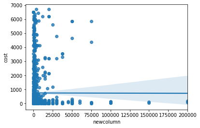

```python
sns.regplot(x="newcolumn",y="cost",data=data_new)
```

```python
X_new = data[['costing_lot_size'
,'material_weight'
,'material_package_size']]
y_new = data['cost']
```

```python
X_train_new, X_test_new, y_train_new, y_test_new = train_test_split(X_new, y_new, test_size = 0.2, random_state = 42)
```

```
Acutal Values: 990     288.429167
1151     19.921111
357      53.503750
1049     49.801111
404      23.854667
Name: cost, dtype: float64
Predicted Values: [ 682  977  189 1117  395]
RMSE (Train Data): 1421.45
RMSE (Test Data): 1421.45
R-Squared (Train Data): 12.0 %
R-Squared (Test Data): -5.0 %
```

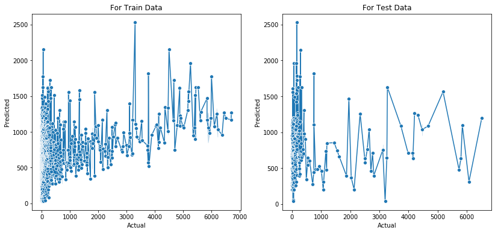

```python
gbr = GradientBoostingRegressor(random_state=0)
gbr.fit(X_train_new, y_train_new)

y_train_pred = np.abs(gbr.predict(X_train_new).astype('int'))
y_test_pred = np.abs(gbr.predict(X_test_new).astype('int'))

print('Acutal Values:', y_test_new[0:5])
print('Predicted Values:', y_test_pred[0:5])
# Estimating RMSE on Train & Test Data
print('RMSE (Train Data):', np.round(np.sqrt(mean_squared_error(y_true = y_test_new, y_pred = y_test_pred)), decimals = 2))
print('RMSE (Test Data):', np.round(np.sqrt(mean_squared_error(y_true = y_test_new, y_pred = y_test_pred)), decimals = 2))
# Estimating R-Squared on Train & Test Data
print('R-Squared (Train Data):', np.round(gbr.score(X_train_new, y_train_new), decimals = 2)*100, '%')
print('R-Squared (Test Data):', np.round(gbr.score(X_test_new, y_test_new), decimals = 2)*100, '%')
# Plotting Acutal vs Predicted values
PlotScore(y_train_new, y_train_pred, y_test_new, y_test_pred)
```

```python
AMYZOL_new_1 = [[20000,20,40]]
AMYZOL_new_pred1 = gbr.predict(AMYZOL_new_1)
AMYZOL_new_pred1
```

```
array([1140.84924829])
```

Model using individual CC2 names

```python
df.head(2)
```

|  | dosage_form_code | material_name | cc2_name | cost | quantity | unit_cost | costing_lot_size |
| --- | --- | --- | --- | --- | --- | --- | --- |
| 0 | FCT | ALENDRONATE SDZ 70MG 4TAB TH | API | 1370.520000 | 6897.430000 | 0.198700 | 17500 |
| 1 | FCT | ALENDRONATE SDZ 70MG 4TAB TH | Other Materials | 7.017778 | 2833.981889 | 0.014453 | 17500 |

```python
for i in range(len(df)):
    #print(df.loc[i,'material_name'])
    #print( re.findall('\d+',df.loc[i,'material_name']))
    l1 = re.findall('\d+',df.loc[i,'material_name'])
    df.loc[i,'material_weight'] = l1[0]
    df.loc[i,'material_package_size'] = l1[1]
```

```python
df["material_weight"] = pd.to_numeric(df["material_weight"])
df["material_package_size"] = pd.to_numeric(df["material_package_size"])
```

```python
df.shape
```

```
(1435, 9)
```

```python
df.cc2_name.value_counts()
```

```
Packaging          479
Other Materials    478
API                478
Name: cc2_name, dtype: int64
```

```python
df_API = df[df['cc2_name'] == 'API']
df_API.head(2)
```

|  | dosage_form_code | material_name | cc2_name | cost | quantity | unit_cost | costing_lot_size | material_weight | material_package_size |
| --- | --- | --- | --- | --- | --- | --- | --- | --- | --- |
| 0 | FCT | ALENDRONATE SDZ 70MG 4TAB TH | API | 1370.52 | 6897.43 | 0.198700 | 17500 | 70 | 4 |
| 3 | FCT | AMYZOL 10MG 100FCT HRV | API | 1084.52 | 5236.17 | 0.207121 | 5000 | 10 | 100 |

```python
df_API.dosage_form_code.value_counts()
```

```
FCT    267
TAB    164
HGC     47
Name: dosage_form_code, dtype: int64
```

```python
df_API.cc2_name.value_counts()
```

```python
df_API.shape
```

```
(478, 9)
```

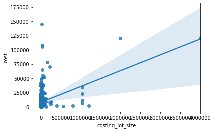

```python
sns.regplot(x="costing_lot_size",y="cost",data=df_API)
```

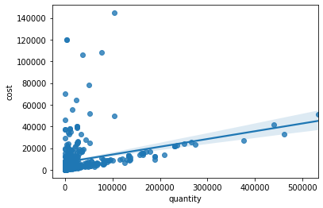

```python
sns.regplot(x="quantity",y="cost",data=df_API)
```

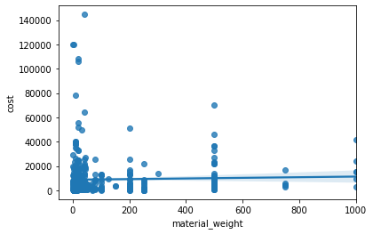

```python
sns.regplot(x="material_weight",y="cost",data=df_API)
```

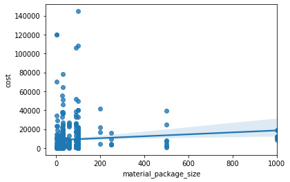

```python
sns.regplot(x="material_package_size",y="cost",data=df_API)
```

```python
df_API = pd.get_dummies(data = df_API, columns = ['dosage_form_code'])
print('Data Shape:', df_API.shape)
```

```
Data Shape: (478, 11)
```

```python
df_API.head(2)
```

|  | material_name | cc2_name | cost | quantity | unit_cost | costing_lot_size | material_weight | material_package_size | dosage_form_code_FCT | dosage_form_code_HGC | dosage_form_code_TAB |
| --- | --- | --- | --- | --- | --- | --- | --- | --- | --- | --- | --- |
| 0 | ALENDRONATE SDZ 70MG 4TAB TH | API | 1370.52 | 6897.43 | 0.198700 | 17500 | 70 | 4 | 1 | 0 | 0 |
| 3 | AMYZOL 10MG 100FCT HRV | API | 1084.52 | 5236.17 | 0.207121 | 5000 | 10 | 100 | 1 | 0 | 0 |

```python
X = df_API.drop(['material_name','cc2_name','cost','unit_cost'], axis = 1)
y = df_API['cost']
```

```python
X_train, X_test, y_train, y_test = train_test_split(X, y, test_size = 0.2, random_state = 42)
```

```
Acutal Values: 1408     8287.81
99        653.17
394      7012.52
216      2897.67
234     13556.44
Name: cost, dtype: float64
Predicted Values: [ 6767  2164  8072  3163 13848]
RMSE (Train Data): 3890.61
RMSE (Test Data): 7458.26
R-Squared (Train Data): 94.0 %
R-Squared (Test Data): 71.0 %
```

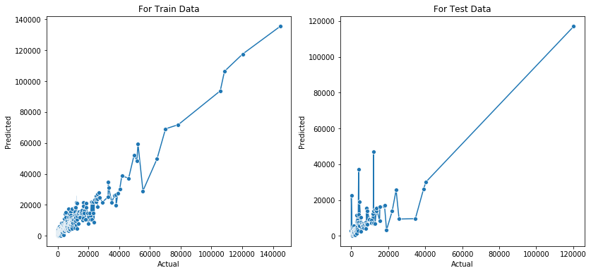

```python
from sklearn.ensemble import GradientBoostingRegressor

gbr = GradientBoostingRegressor(random_state=0)
gbr.fit(X_train, y_train)

y_train_pred = np.abs(gbr.predict(X_train).astype('int'))
y_test_pred = np.abs(gbr.predict(X_test).astype('int'))

print('Acutal Values:', y_test[0:5])
print('Predicted Values:', y_test_pred[0:5])
# Estimating RMSE on Train & Test Data
print('RMSE (Train Data):', np.round(np.sqrt(mean_squared_error(y_true = y_train, y_pred = y_train_pred)), decimals = 2))
print('RMSE (Test Data):', np.round(np.sqrt(mean_squared_error(y_true = y_test, y_pred = y_test_pred)), decimals = 2))
# Estimating R-Squared on Train & Test Data
print('R-Squared (Train Data):', np.round(gbr.score(X_train, y_train), decimals = 2)*100, '%')
print('R-Squared (Test Data):', np.round(gbr.score(X_test, y_test), decimals = 2)*100, '%')
# Plotting Acutal vs Predicted values
PlotScore(y_train, y_train_pred, y_test, y_test_pred)
```